# for() loops

your name here

2/4/2021

# A little refresher on subsetting in R

Subsetting is a big part of writing `for()` loops. If we want to subset something in R, we can use square brackets. What’s in the brackets indicates the **position** of the element we want to subset. Let’s say we have a vector of cereals:

```r
cereal_names <- c("Bran Flakes", "Count Chocula", "Fruit Loops", "Rice Krispies", "Trix")
```

and we want to take out the 3rd cereal in the vector. We can do that using the square brackets like so:

```r
cereal_names[3]
```

```
## [1] "Fruit Loops"
```

Alternatively, you could do something like this:

```r
cereal_names[cereal_names == "Fruit Loops"]
```

```
## [1] "Fruit Loops"
```

Let’s move on to those loops!

# What are `for()` loops?

`for()` loops in R are really powerful tools when you want to do the same thing (i.e. use a set of functions) multiple times on different objects.

There are 3 basic parts for a successful `for()` loop:

1. a set of data to iterate over (usually a vector)
2. an empty vector to hold the output of the loop
3. the `for()` loop itself

First, we’ll need to get our data set to iterate over. We’ll just use the cereal names again.

```r
cereal_names
```

```
## [1] "Bran Flakes"   "Count Chocula" "Fruit Loops"   "Rice Krispies"
## [5] "Trix"
```

Then, we’ll create an empty vector to hold the output of the loop. There are a few ways to do this, but the simplest way is to just create an empty vector using `c()`.

```r
loop_output <- c()
```

Lastly, we have our loop. What you’re telling R to do is:  
- for every element `i` from the first to the last in the vector,  
- perform some operation,  
- and put that into the holding vector.

In this case, we’re saying:  
- for every element `i` from the first to the last in the vector `cereal_names`,  
- make an expression that goes like:  
“[This cereal] is great, but I also like [the previous cereal in the vector]!”  
- and put that into the holding vector.

```r
# for each element i from the first to the last in cereal_names
for(i in 1:length(cereal_names)) {

  # create a temporary object called `expression`
  # use the function `paste()` to create a sentence that goes:
  # [This cereal] is great, and so is [the previous cereal in the vector]!
  expression <- paste(cereal_names[i], " is great, but I also like ", cereal_names[i-1], "!", sep = "")

  # store the value of `expression` in the holding vector
  loop_output[i] <- expression

}
```

And now we can look at our output!

```r
loop_output
```

```
## [1] "Bran Flakes is great, but I also like !"
## [2] "Count Chocula is great, but I also like Bran Flakes!"
## [3] "Fruit Loops is great, but I also like Count Chocula!"
## [4] "Rice Krispies is great, but I also like Fruit Loops!"
## [5] "Trix is great, but I also like Rice Krispies!"
```

# When would you not use a `for()` loop?

Sometimes, you just don’t need a `for()` loop. If what you’re doing can be **vectorized** - as in, one element’s outputs don’t depend on any others - you don’t actually need a loop.

If we just wanted to say, “[This cereal], yum!” without any reference to the other elements in the vector, we don’t actually need a `for()` loop.

```r
paste(cereal_names, ", yum!", sep = "")
```

```
## [1] "Bran Flakes, yum!"   "Count Chocula, yum!" "Fruit Loops, yum!"
## [4] "Rice Krispies, yum!" "Trix, yum!"
```

# What about all those `apply` functions?

**WE DON’T TALK ABOUT THOSE.**

Jk jk. I (An) am not going to cover them because I don’t really know how they work/have never gotten them to work (insert monkey covering face emoji here). Maybe another workshop??

# A bit more complex

I use `for()` loops a lot when I am doing preliminary data visualization. I work with datasets that have 100+ species from a bunch of different sites. For this reason, the tricks for data visualization (e.g. using `facet_wrap()` in `ggplot` to separate plots by some variable) don’t work for me because there are too many species, and too many sites.

Sometimes I want to be able to look at the plots for specific species from specific sites. What I could do is copy paste the code a bunch of times to filter the observations and plot them… or, I could write a `for()` loop to automate the process.

As an example, let’s say we have data on cereal prices for 5 different cereals at 3 different stores, and we want to visualize the change in price over time for each cereal at each store. Also, we can’t use `facet_wrap()` in `ggplot`.

```r
source("data_creation.R")
```

We could do this for every cereal at every store:

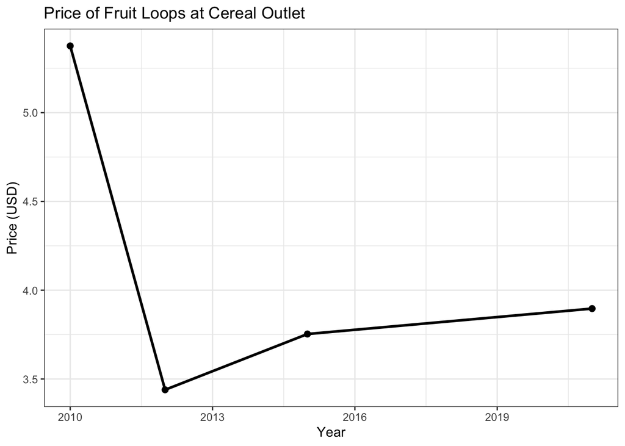

```r
cereal %>%
  filter(store == "cereal_outlet" & cereal == "fruit_loops") %>%
  ggplot(., aes(x = year, y = price_usd)) +
  geom_point(size = 2) +
  geom_line(size = 1) +
  labs(x = "Year",
       y = "Price (USD)",
       title = "Price of Fruit Loops at Cereal Outlet") +
  theme_bw()
```

Or… we could write a `for()` loop. Here’s the basic structure of what’ll be a **nested** `for()` loop (one loop inside the other):  
1. Choose a store (Cereal Outlet, Ce-Mart, or Cer-Ya)  
2. Choose a cereal (Bran Flakes, Count Chocula, Fruit Loops, Rice Krispies, Trix)  
3. Make a timeseries plot of price in USD  
4. Save that plot as an object

To set up, we’re going to create two vectors: one of the 3 store names, and the other of the 5 cereal names.

```r
store <- cereal %>%
  pull(store) %>%
  unique()

cereal_vector <- cereal %>%
  pull(cereal) %>%
  unique()
```

Then, we can write our `for()` loop.

```r
for(j in 1:length(store)) {

  # 1. choose a store
  this_store <- store[j]

  for(i in 1:length(cereal_vector)) {

    # 2. choose a cereal
    this_cereal <- cereal_vector[i]

    # filter the cereal dataset for the observations matching this_store and this_cereal
    this_cereal_data <- cereal %>% filter(store == this_store & cereal == this_cereal)

    # make a timeseries plot of price in USD
    plot <- ggplot(this_cereal_data, aes(x = year, y = price_usd)) +
      geom_point(size = 2) +
      geom_line(size = 1) +
      labs(x = "Year",
           y = "Price (USD)",
           # with a dynamic name!
           title = paste("Price of ", this_cereal_data$cereal_title, " at ",
                         this_cereal_data$store_title, sep = "")) +
      theme_bw()

    # make a separate object for the plot with a dynamic name
    # the first argument is the object name (e.g. plot_cer_ya_trix)
    # the second argumetn is the object (the temporary `plot`)
    assign(paste("plot", this_store, this_cereal, sep = "_"), plot)

  }

}
```

Now, we can look at our plots.

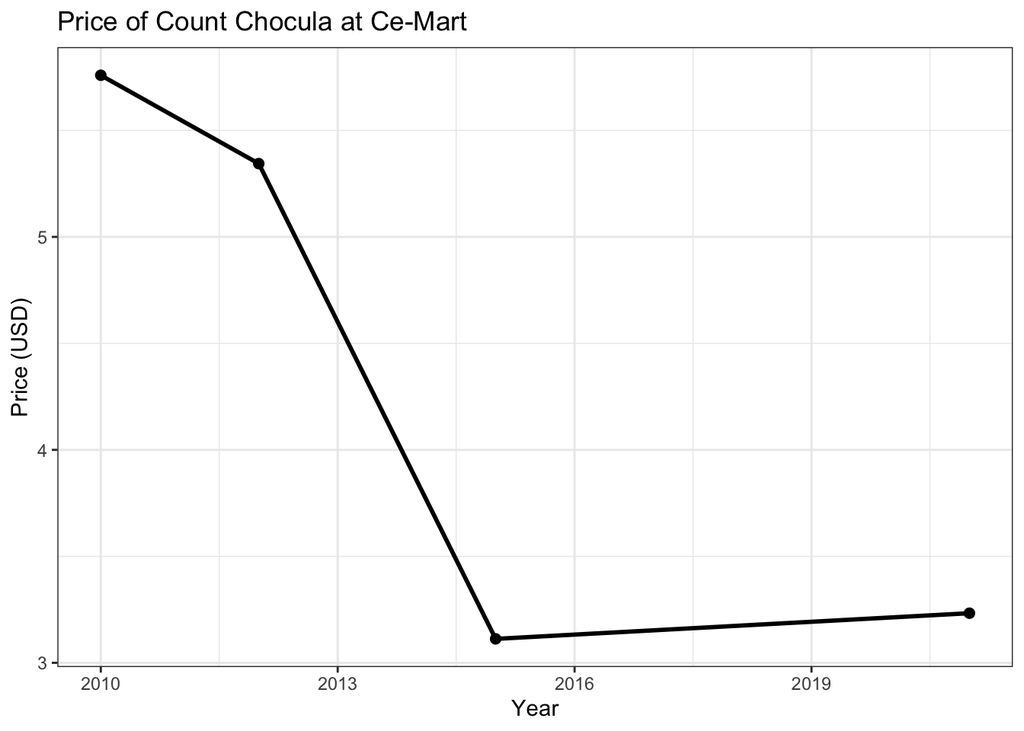

```r
plot_ce_mart_count_chocula
```

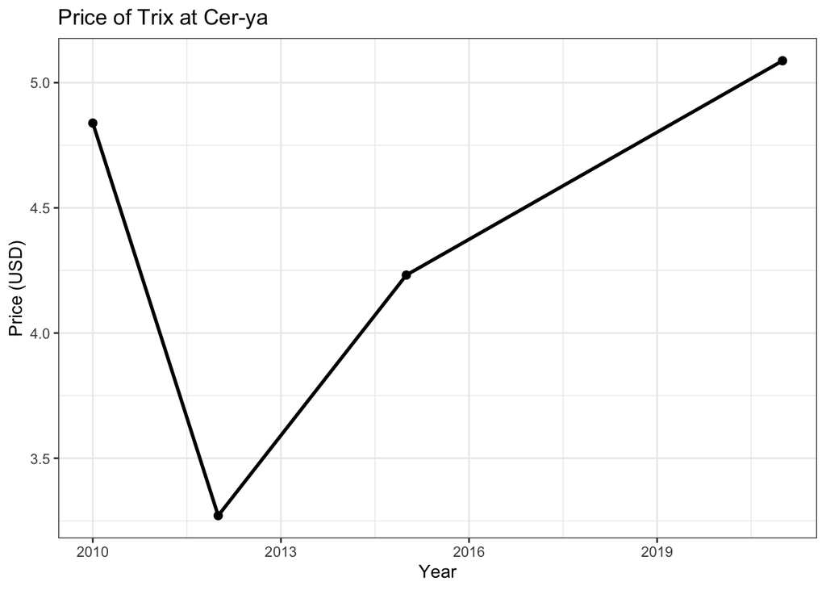

```r
plot_cer_ya_trix
```

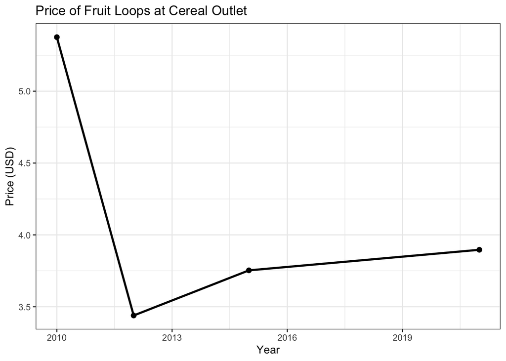

```r
plot_cereal_outlet_fruit_loops
```